# Risk Factor Analysis

## Outcome Variable

**Outcome Variable:** y_rate_haz

## Predictor Variables

**Intervention Variable:** vagbrth

**Adjustment Set:**

unadjusted

## Stratifying Variables

The analysis was stratified on these variable(s):

- agecat
- studyid
- country

## Data Summary

| agecat | studyid | country | vagbrth | n_cell | n |
| --- | --- | --- | --- | --- | --- |
| 0-3 months | ki1000108-CMC-V-BCS-2002 | INDIA | 0 | 10 | 87 |
| 0-3 months | ki1000108-CMC-V-BCS-2002 | INDIA | 1 | 77 | 87 |
| 0-3 months | ki1000108-IRC | INDIA | 0 | 66 | 377 |
| 0-3 months | ki1000108-IRC | INDIA | 1 | 311 | 377 |
| 0-3 months | ki1017093b-PROVIDE | BANGLADESH | 0 | 148 | 634 |
| 0-3 months | ki1017093b-PROVIDE | BANGLADESH | 1 | 486 | 634 |
| 0-3 months | ki1017093c-NIH-Crypto | BANGLADESH | 0 | 193 | 469 |
| 0-3 months | ki1017093c-NIH-Crypto | BANGLADESH | 1 | 276 | 469 |
| 0-3 months | ki1119695-PROBIT | BELARUS | 0 | 1424 | 12745 |
| 0-3 months | ki1119695-PROBIT | BELARUS | 1 | 11321 | 12745 |
| 0-3 months | ki1126311-ZVITAMBO | ZIMBABWE | 0 | 683 | 7802 |
| 0-3 months | ki1126311-ZVITAMBO | ZIMBABWE | 1 | 7119 | 7802 |
| 0-3 months | kiGH5241-JiVitA-3 | BANGLADESH | 0 | 1704 | 40020 |
| 0-3 months | kiGH5241-JiVitA-3 | BANGLADESH | 1 | 38316 | 40020 |
| 0-3 months | kiGH5241-JiVitA-4 | BANGLADESH | 0 | 200 | 3610 |
| 0-3 months | kiGH5241-JiVitA-4 | BANGLADESH | 1 | 3410 | 3610 |
| 3-6 months | ki1000108-CMC-V-BCS-2002 | INDIA | 0 | 21 | 307 |
| 3-6 months | ki1000108-CMC-V-BCS-2002 | INDIA | 1 | 286 | 307 |
| 3-6 months | ki1000108-IRC | INDIA | 0 | 67 | 397 |
| 3-6 months | ki1000108-IRC | INDIA | 1 | 330 | 397 |
| 3-6 months | ki1017093b-PROVIDE | BANGLADESH | 0 | 133 | 574 |
| 3-6 months | ki1017093b-PROVIDE | BANGLADESH | 1 | 441 | 574 |
| 3-6 months | ki1017093c-NIH-Crypto | BANGLADESH | 0 | 182 | 443 |
| 3-6 months | ki1017093c-NIH-Crypto | BANGLADESH | 1 | 261 | 443 |
| 3-6 months | ki1066203-TanzaniaChild2 | TANZANIA, UNITED REPUBLIC OF | 0 | 159 | 1641 |
| 3-6 months | ki1066203-TanzaniaChild2 | TANZANIA, UNITED REPUBLIC OF | 1 | 1482 | 1641 |
| 3-6 months | ki1119695-PROBIT | BELARUS | 0 | 1473 | 13309 |
| 3-6 months | ki1119695-PROBIT | BELARUS | 1 | 11836 | 13309 |
| 3-6 months | ki1126311-ZVITAMBO | ZIMBABWE | 0 | 509 | 5842 |
| 3-6 months | ki1126311-ZVITAMBO | ZIMBABWE | 1 | 5333 | 5842 |
| 3-6 months | kiGH5241-JiVitA-3 | BANGLADESH | 0 | 1538 | 25100 |
| 3-6 months | kiGH5241-JiVitA-3 | BANGLADESH | 1 | 23562 | 25100 |
| 3-6 months | kiGH5241-JiVitA-4 | BANGLADESH | 0 | 256 | 3524 |
| 3-6 months | kiGH5241-JiVitA-4 | BANGLADESH | 1 | 3268 | 3524 |
| 6-12 months | ki1000108-CMC-V-BCS-2002 | INDIA | 0 | 22 | 323 |
| 6-12 months | ki1000108-CMC-V-BCS-2002 | INDIA | 1 | 301 | 323 |
| 6-12 months | ki1000108-IRC | INDIA | 0 | 68 | 400 |
| 6-12 months | ki1000108-IRC | INDIA | 1 | 332 | 400 |
| 6-12 months | ki1017093b-PROVIDE | BANGLADESH | 0 | 121 | 545 |
| 6-12 months | ki1017093b-PROVIDE | BANGLADESH | 1 | 424 | 545 |
| 6-12 months | ki1017093c-NIH-Crypto | BANGLADESH | 0 | 176 | 420 |
| 6-12 months | ki1017093c-NIH-Crypto | BANGLADESH | 1 | 244 | 420 |
| 6-12 months | ki1066203-TanzaniaChild2 | TANZANIA, UNITED REPUBLIC OF | 0 | 102 | 1065 |
| 6-12 months | ki1066203-TanzaniaChild2 | TANZANIA, UNITED REPUBLIC OF | 1 | 963 | 1065 |
| 6-12 months | ki1119695-PROBIT | BELARUS | 0 | 1444 | 12896 |
| 6-12 months | ki1119695-PROBIT | BELARUS | 1 | 11452 | 12896 |
| 6-12 months | ki1126311-ZVITAMBO | ZIMBABWE | 0 | 369 | 4533 |
| 6-12 months | ki1126311-ZVITAMBO | ZIMBABWE | 1 | 4164 | 4533 |
| 6-12 months | kiGH5241-JiVitA-3 | BANGLADESH | 0 | 1182 | 19606 |
| 6-12 months | kiGH5241-JiVitA-3 | BANGLADESH | 1 | 18424 | 19606 |
| 6-12 months | kiGH5241-JiVitA-4 | BANGLADESH | 0 | 474 | 5610 |
| 6-12 months | kiGH5241-JiVitA-4 | BANGLADESH | 1 | 5136 | 5610 |
| 12-24 months | ki1000108-CMC-V-BCS-2002 | INDIA | 0 | 23 | 324 |
| 12-24 months | ki1000108-CMC-V-BCS-2002 | INDIA | 1 | 301 | 324 |
| 12-24 months | ki1000108-IRC | INDIA | 0 | 67 | 396 |
| 12-24 months | ki1000108-IRC | INDIA | 1 | 329 | 396 |
| 12-24 months | ki1017093b-PROVIDE | BANGLADESH | 0 | 101 | 458 |
| 12-24 months | ki1017093b-PROVIDE | BANGLADESH | 1 | 357 | 458 |
| 12-24 months | ki1017093c-NIH-Crypto | BANGLADESH | 0 | 94 | 241 |
| 12-24 months | ki1017093c-NIH-Crypto | BANGLADESH | 1 | 147 | 241 |
| 12-24 months | ki1066203-TanzaniaChild2 | TANZANIA, UNITED REPUBLIC OF | 0 | 1 | 2 |
| 12-24 months | ki1066203-TanzaniaChild2 | TANZANIA, UNITED REPUBLIC OF | 1 | 1 | 2 |
| 12-24 months | ki1119695-PROBIT | BELARUS | 0 | 298 | 2533 |
| 12-24 months | ki1119695-PROBIT | BELARUS | 1 | 2235 | 2533 |
| 12-24 months | ki1126311-ZVITAMBO | ZIMBABWE | 0 | 20 | 297 |
| 12-24 months | ki1126311-ZVITAMBO | ZIMBABWE | 1 | 277 | 297 |
| 12-24 months | kiGH5241-JiVitA-3 | BANGLADESH | 0 | 524 | 9252 |
| 12-24 months | kiGH5241-JiVitA-3 | BANGLADESH | 1 | 8728 | 9252 |
| 12-24 months | kiGH5241-JiVitA-4 | BANGLADESH | 0 | 513 | 6223 |
| 12-24 months | kiGH5241-JiVitA-4 | BANGLADESH | 1 | 5710 | 6223 |

The following strata were considered:

- agecat: 0-3 months, studyid: ki1000108-CMC-V-BCS-2002, country: INDIA
- agecat: 0-3 months, studyid: ki1000108-IRC, country: INDIA
- agecat: 0-3 months, studyid: ki1017093b-PROVIDE, country: BANGLADESH
- agecat: 0-3 months, studyid: ki1017093c-NIH-Crypto, country: BANGLADESH
- agecat: 0-3 months, studyid: ki1119695-PROBIT, country: BELARUS
- agecat: 0-3 months, studyid: ki1126311-ZVITAMBO, country: ZIMBABWE
- agecat: 0-3 months, studyid: kiGH5241-JiVitA-3, country: BANGLADESH
- agecat: 0-3 months, studyid: kiGH5241-JiVitA-4, country: BANGLADESH
- agecat: 12-24 months, studyid: ki1000108-CMC-V-BCS-2002, country: INDIA
- agecat: 12-24 months, studyid: ki1000108-IRC, country: INDIA
- agecat: 12-24 months, studyid: ki1017093b-PROVIDE, country: BANGLADESH
- agecat: 12-24 months, studyid: ki1017093c-NIH-Crypto, country: BANGLADESH
- agecat: 12-24 months, studyid: ki1066203-TanzaniaChild2, country: TANZANIA, UNITED REPUBLIC OF
- agecat: 12-24 months, studyid: ki1119695-PROBIT, country: BELARUS
- agecat: 12-24 months, studyid: ki1126311-ZVITAMBO, country: ZIMBABWE
- agecat: 12-24 months, studyid: kiGH5241-JiVitA-3, country: BANGLADESH
- agecat: 12-24 months, studyid: kiGH5241-JiVitA-4, country: BANGLADESH
- agecat: 3-6 months, studyid: ki1000108-CMC-V-BCS-2002, country: INDIA
- agecat: 3-6 months, studyid: ki1000108-IRC, country: INDIA
- agecat: 3-6 months, studyid: ki1017093b-PROVIDE, country: BANGLADESH
- agecat: 3-6 months, studyid: ki1017093c-NIH-Crypto, country: BANGLADESH
- agecat: 3-6 months, studyid: ki1066203-TanzaniaChild2, country: TANZANIA, UNITED REPUBLIC OF
- agecat: 3-6 months, studyid: ki1119695-PROBIT, country: BELARUS
- agecat: 3-6 months, studyid: ki1126311-ZVITAMBO, country: ZIMBABWE
- agecat: 3-6 months, studyid: kiGH5241-JiVitA-3, country: BANGLADESH
- agecat: 3-6 months, studyid: kiGH5241-JiVitA-4, country: BANGLADESH
- agecat: 6-12 months, studyid: ki1000108-CMC-V-BCS-2002, country: INDIA
- agecat: 6-12 months, studyid: ki1000108-IRC, country: INDIA
- agecat: 6-12 months, studyid: ki1017093b-PROVIDE, country: BANGLADESH
- agecat: 6-12 months, studyid: ki1017093c-NIH-Crypto, country: BANGLADESH
- agecat: 6-12 months, studyid: ki1066203-TanzaniaChild2, country: TANZANIA, UNITED REPUBLIC OF
- agecat: 6-12 months, studyid: ki1119695-PROBIT, country: BELARUS
- agecat: 6-12 months, studyid: ki1126311-ZVITAMBO, country: ZIMBABWE
- agecat: 6-12 months, studyid: kiGH5241-JiVitA-3, country: BANGLADESH
- agecat: 6-12 months, studyid: kiGH5241-JiVitA-4, country: BANGLADESH

### Dropped Strata

Some strata were dropped due to rare outcomes:

- agecat: 12-24 months, studyid: ki1066203-TanzaniaChild2, country: TANZANIA, UNITED REPUBLIC OF

## Methods Detail

We’re interested in the causal parameters $E[Y_a]$ for all values of $a \in \mathcal{A}$. These parameters represent the mean outcome if, possibly contrary to fact, we intervened to set all units to have $A=a$. Under the randomization and positivity assumptions, these are identified by the statistical parameters $\psi_a=E_W[E_{Y|A,W}(Y|A=a,W)]$. In addition, we’re interested in the mean of $Y$, $E[Y]$ under no intervention (the observed mean). We will estimate these parameters by using SuperLearner to fit the relevant likelihood factors – $E_{Y|A,W}(Y|A=a,W)$ and $p(A=a|W)$, and then updating our likelihood fit using a joint TMLE.

For unadjusted analyses ($W=\{\}$), initial likelihoods were estimated using Lrnr_glm to estimate the simple $E(Y|A)$ and Lrnr_mean to estimate $p(A)$. For adjusted analyses, a small library containing Lrnr_glmnet, Lrnr_xgboost, and Lrnr_mean was used.

Having estimated these parameters, we will then use the delta method to estimate relative risks and attributable risks relative to a prespecified baseline level of $A$.

# Results Detail

## Results Plots

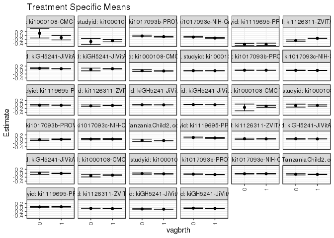

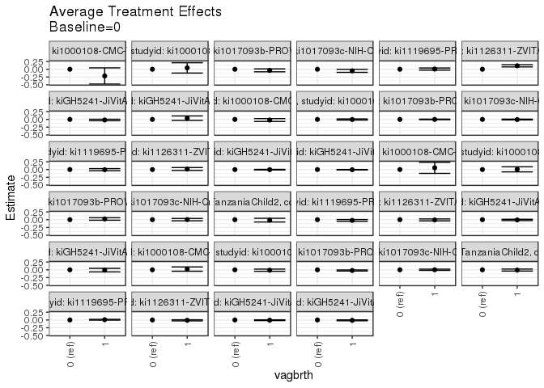

## Results Table

### Parameter: TSM

| agecat | studyid | country | intervention_level | baseline_level | estimate | ci_lower | ci_upper |
| --- | --- | --- | --- | --- | --- | --- | --- |
| 0-3 months | ki1000108-CMC-V-BCS-2002 | INDIA | 0 | NA | 0.1172875 | -0.1158481 | 0.3504232 |
| 0-3 months | ki1000108-CMC-V-BCS-2002 | INDIA | 1 | NA | -0.0980462 | -0.2143438 | 0.0182514 |
| 0-3 months | ki1000108-IRC | INDIA | 0 | NA | -0.2956980 | -0.4515384 | -0.1398576 |
| 0-3 months | ki1000108-IRC | INDIA | 1 | NA | -0.2518137 | -0.3109986 | -0.1926288 |
| 0-3 months | ki1017093b-PROVIDE | BANGLADESH | 0 | NA | -0.0138869 | -0.0559543 | 0.0281806 |
| 0-3 months | ki1017093b-PROVIDE | BANGLADESH | 1 | NA | -0.0496667 | -0.0695223 | -0.0298110 |
| 0-3 months | ki1017093c-NIH-Crypto | BANGLADESH | 0 | NA | -0.0687556 | -0.1066504 | -0.0308607 |
| 0-3 months | ki1017093c-NIH-Crypto | BANGLADESH | 1 | NA | -0.1188747 | -0.1508922 | -0.0868572 |
| 0-3 months | ki1119695-PROBIT | BELARUS | 0 | NA | -0.4433356 | -0.5014058 | -0.3852653 |
| 0-3 months | ki1119695-PROBIT | BELARUS | 1 | NA | -0.4368672 | -0.4974544 | -0.3762800 |
| 0-3 months | ki1126311-ZVITAMBO | ZIMBABWE | 0 | NA | -0.2456002 | -0.2792603 | -0.2119400 |
| 0-3 months | ki1126311-ZVITAMBO | ZIMBABWE | 1 | NA | -0.1340683 | -0.1450246 | -0.1231119 |
| 0-3 months | kiGH5241-JiVitA-3 | BANGLADESH | 0 | NA | 0.0881041 | 0.0643940 | 0.1118142 |
| 0-3 months | kiGH5241-JiVitA-3 | BANGLADESH | 1 | NA | 0.0697865 | 0.0646992 | 0.0748739 |
| 0-3 months | kiGH5241-JiVitA-4 | BANGLADESH | 0 | NA | 0.0300017 | -0.0399086 | 0.0999120 |
| 0-3 months | kiGH5241-JiVitA-4 | BANGLADESH | 1 | NA | 0.0694710 | 0.0540590 | 0.0848831 |
| 3-6 months | ki1000108-CMC-V-BCS-2002 | INDIA | 0 | NA | -0.1496482 | -0.3216775 | 0.0223812 |
| 3-6 months | ki1000108-CMC-V-BCS-2002 | INDIA | 1 | NA | -0.0941663 | -0.1436836 | -0.0446491 |
| 3-6 months | ki1000108-IRC | INDIA | 0 | NA | -0.0569315 | -0.1313094 | 0.0174464 |
| 3-6 months | ki1000108-IRC | INDIA | 1 | NA | -0.0508686 | -0.0837706 | -0.0179666 |
| 3-6 months | ki1017093b-PROVIDE | BANGLADESH | 0 | NA | -0.0442034 | -0.0793596 | -0.0090473 |
| 3-6 months | ki1017093b-PROVIDE | BANGLADESH | 1 | NA | -0.0221277 | -0.0407067 | -0.0035487 |
| 3-6 months | ki1017093c-NIH-Crypto | BANGLADESH | 0 | NA | -0.0123906 | -0.0427971 | 0.0180158 |
| 3-6 months | ki1017093c-NIH-Crypto | BANGLADESH | 1 | NA | -0.0108551 | -0.0346816 | 0.0129713 |
| 3-6 months | ki1066203-TanzaniaChild2 | TANZANIA, UNITED REPUBLIC OF | 0 | NA | -0.0712699 | -0.1281048 | -0.0144350 |
| 3-6 months | ki1066203-TanzaniaChild2 | TANZANIA, UNITED REPUBLIC OF | 1 | NA | -0.0860182 | -0.1035991 | -0.0684373 |
| 3-6 months | ki1119695-PROBIT | BELARUS | 0 | NA | 0.0679022 | 0.0435200 | 0.0922844 |
| 3-6 months | ki1119695-PROBIT | BELARUS | 1 | NA | 0.0444865 | 0.0237462 | 0.0652267 |
| 3-6 months | ki1126311-ZVITAMBO | ZIMBABWE | 0 | NA | 0.0052017 | -0.0248550 | 0.0352584 |
| 3-6 months | ki1126311-ZVITAMBO | ZIMBABWE | 1 | NA | -0.0025909 | -0.0124423 | 0.0072605 |
| 3-6 months | kiGH5241-JiVitA-3 | BANGLADESH | 0 | NA | 0.0041860 | -0.0161038 | 0.0244759 |
| 3-6 months | kiGH5241-JiVitA-3 | BANGLADESH | 1 | NA | -0.0039800 | -0.0090401 | 0.0010801 |
| 3-6 months | kiGH5241-JiVitA-4 | BANGLADESH | 0 | NA | -0.0003222 | -0.0568602 | 0.0562157 |
| 3-6 months | kiGH5241-JiVitA-4 | BANGLADESH | 1 | NA | -0.0098512 | -0.0242042 | 0.0045018 |
| 6-12 months | ki1000108-CMC-V-BCS-2002 | INDIA | 0 | NA | -0.1211446 | -0.1867833 | -0.0555060 |
| 6-12 months | ki1000108-CMC-V-BCS-2002 | INDIA | 1 | NA | -0.0977457 | -0.1192707 | -0.0762208 |
| 6-12 months | ki1000108-IRC | INDIA | 0 | NA | -0.0158461 | -0.0481699 | 0.0164777 |
| 6-12 months | ki1000108-IRC | INDIA | 1 | NA | -0.0280979 | -0.0421451 | -0.0140507 |
| 6-12 months | ki1017093b-PROVIDE | BANGLADESH | 0 | NA | -0.0460805 | -0.0612808 | -0.0308803 |
| 6-12 months | ki1017093b-PROVIDE | BANGLADESH | 1 | NA | -0.0673337 | -0.0750733 | -0.0595942 |
| 6-12 months | ki1017093c-NIH-Crypto | BANGLADESH | 0 | NA | -0.0242592 | -0.0388115 | -0.0097070 |
| 6-12 months | ki1017093c-NIH-Crypto | BANGLADESH | 1 | NA | -0.0227202 | -0.0355622 | -0.0098782 |
| 6-12 months | ki1066203-TanzaniaChild2 | TANZANIA, UNITED REPUBLIC OF | 0 | NA | -0.0524279 | -0.0834517 | -0.0214042 |
| 6-12 months | ki1066203-TanzaniaChild2 | TANZANIA, UNITED REPUBLIC OF | 1 | NA | -0.0603407 | -0.0700819 | -0.0505996 |
| 6-12 months | ki1119695-PROBIT | BELARUS | 0 | NA | 0.0356550 | 0.0178048 | 0.0535053 |
| 6-12 months | ki1119695-PROBIT | BELARUS | 1 | NA | 0.0431235 | 0.0262646 | 0.0599825 |
| 6-12 months | ki1126311-ZVITAMBO | ZIMBABWE | 0 | NA | -0.0385585 | -0.0555982 | -0.0215188 |
| 6-12 months | ki1126311-ZVITAMBO | ZIMBABWE | 1 | NA | -0.0497628 | -0.0546082 | -0.0449174 |
| 6-12 months | kiGH5241-JiVitA-3 | BANGLADESH | 0 | NA | -0.0671239 | -0.0800291 | -0.0542187 |
| 6-12 months | kiGH5241-JiVitA-3 | BANGLADESH | 1 | NA | -0.0753682 | -0.0783010 | -0.0724353 |
| 6-12 months | kiGH5241-JiVitA-4 | BANGLADESH | 0 | NA | -0.0261949 | -0.0396643 | -0.0127255 |
| 6-12 months | kiGH5241-JiVitA-4 | BANGLADESH | 1 | NA | -0.0384724 | -0.0432258 | -0.0337191 |
| 12-24 months | ki1000108-CMC-V-BCS-2002 | INDIA | 0 | NA | -0.0271023 | -0.0720727 | 0.0178681 |
| 12-24 months | ki1000108-CMC-V-BCS-2002 | INDIA | 1 | NA | -0.0469256 | -0.0573074 | -0.0365438 |
| 12-24 months | ki1000108-IRC | INDIA | 0 | NA | -0.0290299 | -0.0457822 | -0.0122777 |
| 12-24 months | ki1000108-IRC | INDIA | 1 | NA | -0.0323264 | -0.0401171 | -0.0245357 |
| 12-24 months | ki1017093b-PROVIDE | BANGLADESH | 0 | NA | -0.0079002 | -0.0167754 | 0.0009750 |
| 12-24 months | ki1017093b-PROVIDE | BANGLADESH | 1 | NA | -0.0082486 | -0.0124891 | -0.0040081 |
| 12-24 months | ki1017093c-NIH-Crypto | BANGLADESH | 0 | NA | -0.0122841 | -0.0225691 | -0.0019990 |
| 12-24 months | ki1017093c-NIH-Crypto | BANGLADESH | 1 | NA | -0.0166303 | -0.0234141 | -0.0098465 |
| 12-24 months | ki1119695-PROBIT | BELARUS | 0 | NA | -0.0382392 | -0.0722100 | -0.0042685 |
| 12-24 months | ki1119695-PROBIT | BELARUS | 1 | NA | -0.0436911 | -0.0619355 | -0.0254467 |
| 12-24 months | ki1126311-ZVITAMBO | ZIMBABWE | 0 | NA | -0.0677260 | -0.1129912 | -0.0224609 |
| 12-24 months | ki1126311-ZVITAMBO | ZIMBABWE | 1 | NA | -0.0505390 | -0.0599674 | -0.0411105 |
| 12-24 months | kiGH5241-JiVitA-3 | BANGLADESH | 0 | NA | -0.0155719 | -0.0243157 | -0.0068281 |
| 12-24 months | kiGH5241-JiVitA-3 | BANGLADESH | 1 | NA | -0.0190029 | -0.0208757 | -0.0171301 |
| 12-24 months | kiGH5241-JiVitA-4 | BANGLADESH | 0 | NA | -0.0091944 | -0.0160046 | -0.0023842 |
| 12-24 months | kiGH5241-JiVitA-4 | BANGLADESH | 1 | NA | -0.0146182 | -0.0167489 | -0.0124875 |

### Parameter: E(Y)

| agecat | studyid | country | intervention_level | baseline_level | estimate | ci_lower | ci_upper |
| --- | --- | --- | --- | --- | --- | --- | --- |
| 0-3 months | ki1000108-CMC-V-BCS-2002 | INDIA | NA | NA | -0.0732952 | -0.1806423 | 0.0340519 |
| 0-3 months | ki1000108-IRC | INDIA | NA | NA | -0.2594964 | -0.3154509 | -0.2035418 |
| 0-3 months | ki1017093b-PROVIDE | BANGLADESH | NA | NA | -0.0413143 | -0.0594662 | -0.0231624 |
| 0-3 months | ki1017093c-NIH-Crypto | BANGLADESH | NA | NA | -0.0982500 | -0.1228099 | -0.0736901 |
| 0-3 months | ki1119695-PROBIT | BELARUS | NA | NA | -0.4375900 | -0.4969173 | -0.3782626 |
| 0-3 months | ki1126311-ZVITAMBO | ZIMBABWE | NA | NA | -0.1438320 | -0.1542778 | -0.1333861 |
| 0-3 months | kiGH5241-JiVitA-3 | BANGLADESH | NA | NA | 0.0705665 | 0.0656128 | 0.0755202 |
| 0-3 months | kiGH5241-JiVitA-4 | BANGLADESH | NA | NA | 0.0672843 | 0.0522760 | 0.0822927 |
| 3-6 months | ki1000108-CMC-V-BCS-2002 | INDIA | NA | NA | -0.0979615 | -0.1455947 | -0.0503283 |
| 3-6 months | ki1000108-IRC | INDIA | NA | NA | -0.0518918 | -0.0819849 | -0.0217987 |
| 3-6 months | ki1017093b-PROVIDE | BANGLADESH | NA | NA | -0.0272428 | -0.0436954 | -0.0107902 |
| 3-6 months | ki1017093c-NIH-Crypto | BANGLADESH | NA | NA | -0.0114860 | -0.0302773 | 0.0073054 |
| 3-6 months | ki1066203-TanzaniaChild2 | TANZANIA, UNITED REPUBLIC OF | NA | NA | -0.0845892 | -0.1013959 | -0.0677825 |
| 3-6 months | ki1119695-PROBIT | BELARUS | NA | NA | 0.0470780 | 0.0278572 | 0.0662989 |
| 3-6 months | ki1126311-ZVITAMBO | ZIMBABWE | NA | NA | -0.0019119 | -0.0112787 | 0.0074549 |
| 3-6 months | kiGH5241-JiVitA-3 | BANGLADESH | NA | NA | -0.0034796 | -0.0083626 | 0.0014034 |
| 3-6 months | kiGH5241-JiVitA-4 | BANGLADESH | NA | NA | -0.0091589 | -0.0232046 | 0.0048867 |
| 6-12 months | ki1000108-CMC-V-BCS-2002 | INDIA | NA | NA | -0.0993395 | -0.1199006 | -0.0787784 |
| 6-12 months | ki1000108-IRC | INDIA | NA | NA | -0.0260151 | -0.0389122 | -0.0131180 |
| 6-12 months | ki1017093b-PROVIDE | BANGLADESH | NA | NA | -0.0626151 | -0.0695574 | -0.0556729 |
| 6-12 months | ki1017093c-NIH-Crypto | BANGLADESH | NA | NA | -0.0233651 | -0.0330011 | -0.0137291 |
| 6-12 months | ki1066203-TanzaniaChild2 | TANZANIA, UNITED REPUBLIC OF | NA | NA | -0.0595829 | -0.0688798 | -0.0502860 |
| 6-12 months | ki1119695-PROBIT | BELARUS | NA | NA | 0.0422873 | 0.0257506 | 0.0588239 |
| 6-12 months | ki1126311-ZVITAMBO | ZIMBABWE | NA | NA | -0.0488507 | -0.0535137 | -0.0441878 |
| 6-12 months | kiGH5241-JiVitA-3 | BANGLADESH | NA | NA | -0.0748712 | -0.0777013 | -0.0720410 |
| 6-12 months | kiGH5241-JiVitA-4 | BANGLADESH | NA | NA | -0.0374351 | -0.0419740 | -0.0328961 |
| 12-24 months | ki1000108-CMC-V-BCS-2002 | INDIA | NA | NA | -0.0455184 | -0.0556929 | -0.0353439 |
| 12-24 months | ki1000108-IRC | INDIA | NA | NA | -0.0317687 | -0.0388357 | -0.0247017 |
| 12-24 months | ki1017093b-PROVIDE | BANGLADESH | NA | NA | -0.0081718 | -0.0120131 | -0.0043304 |
| 12-24 months | ki1017093c-NIH-Crypto | BANGLADESH | NA | NA | -0.0149351 | -0.0207045 | -0.0091656 |
| 12-24 months | ki1119695-PROBIT | BELARUS | NA | NA | -0.0430497 | -0.0603171 | -0.0257823 |
| 12-24 months | ki1126311-ZVITAMBO | ZIMBABWE | NA | NA | -0.0516964 | -0.0610161 | -0.0423766 |
| 12-24 months | kiGH5241-JiVitA-3 | BANGLADESH | NA | NA | -0.0188086 | -0.0206601 | -0.0169571 |
| 12-24 months | kiGH5241-JiVitA-4 | BANGLADESH | NA | NA | -0.0141711 | -0.0162327 | -0.0121095 |

### Parameter: ATE

| agecat | studyid | country | intervention_level | baseline_level | estimate | ci_lower | ci_upper |
| --- | --- | --- | --- | --- | --- | --- | --- |
| 0-3 months | ki1000108-CMC-V-BCS-2002 | INDIA | 0 | 0 | 0.0000000 | 0.0000000 | 0.0000000 |
| 0-3 months | ki1000108-CMC-V-BCS-2002 | INDIA | 1 | 0 | -0.2153337 | -0.4758666 | 0.0451991 |
| 0-3 months | ki1000108-IRC | INDIA | 0 | 0 | 0.0000000 | 0.0000000 | 0.0000000 |
| 0-3 months | ki1000108-IRC | INDIA | 1 | 0 | 0.0438843 | -0.1228163 | 0.2105849 |
| 0-3 months | ki1017093b-PROVIDE | BANGLADESH | 0 | 0 | 0.0000000 | 0.0000000 | 0.0000000 |
| 0-3 months | ki1017093b-PROVIDE | BANGLADESH | 1 | 0 | -0.0357798 | -0.0822977 | 0.0107381 |
| 0-3 months | ki1017093c-NIH-Crypto | BANGLADESH | 0 | 0 | 0.0000000 | 0.0000000 | 0.0000000 |
| 0-3 months | ki1017093c-NIH-Crypto | BANGLADESH | 1 | 0 | -0.0501191 | -0.0997290 | -0.0005093 |
| 0-3 months | ki1119695-PROBIT | BELARUS | 0 | 0 | 0.0000000 | 0.0000000 | 0.0000000 |
| 0-3 months | ki1119695-PROBIT | BELARUS | 1 | 0 | 0.0064683 | -0.0272772 | 0.0402138 |
| 0-3 months | ki1126311-ZVITAMBO | ZIMBABWE | 0 | 0 | 0.0000000 | 0.0000000 | 0.0000000 |
| 0-3 months | ki1126311-ZVITAMBO | ZIMBABWE | 1 | 0 | 0.1115319 | 0.0761335 | 0.1469303 |
| 0-3 months | kiGH5241-JiVitA-3 | BANGLADESH | 0 | 0 | 0.0000000 | 0.0000000 | 0.0000000 |
| 0-3 months | kiGH5241-JiVitA-3 | BANGLADESH | 1 | 0 | -0.0183176 | -0.0426940 | 0.0060588 |
| 0-3 months | kiGH5241-JiVitA-4 | BANGLADESH | 0 | 0 | 0.0000000 | 0.0000000 | 0.0000000 |
| 0-3 months | kiGH5241-JiVitA-4 | BANGLADESH | 1 | 0 | 0.0394693 | -0.0323923 | 0.1113309 |
| 3-6 months | ki1000108-CMC-V-BCS-2002 | INDIA | 0 | 0 | 0.0000000 | 0.0000000 | 0.0000000 |
| 3-6 months | ki1000108-CMC-V-BCS-2002 | INDIA | 1 | 0 | 0.0554819 | -0.1235323 | 0.2344960 |
| 3-6 months | ki1000108-IRC | INDIA | 0 | 0 | 0.0000000 | 0.0000000 | 0.0000000 |
| 3-6 months | ki1000108-IRC | INDIA | 1 | 0 | 0.0060629 | -0.0752673 | 0.0873931 |
| 3-6 months | ki1017093b-PROVIDE | BANGLADESH | 0 | 0 | 0.0000000 | 0.0000000 | 0.0000000 |
| 3-6 months | ki1017093b-PROVIDE | BANGLADESH | 1 | 0 | 0.0220758 | -0.0176877 | 0.0618392 |
| 3-6 months | ki1017093c-NIH-Crypto | BANGLADESH | 0 | 0 | 0.0000000 | 0.0000000 | 0.0000000 |
| 3-6 months | ki1017093c-NIH-Crypto | BANGLADESH | 1 | 0 | 0.0015355 | -0.0370942 | 0.0401652 |
| 3-6 months | ki1066203-TanzaniaChild2 | TANZANIA, UNITED REPUBLIC OF | 0 | 0 | 0.0000000 | 0.0000000 | 0.0000000 |
| 3-6 months | ki1066203-TanzaniaChild2 | TANZANIA, UNITED REPUBLIC OF | 1 | 0 | -0.0147483 | -0.0742403 | 0.0447437 |
| 3-6 months | ki1119695-PROBIT | BELARUS | 0 | 0 | 0.0000000 | 0.0000000 | 0.0000000 |
| 3-6 months | ki1119695-PROBIT | BELARUS | 1 | 0 | -0.0234157 | -0.0518779 | 0.0050465 |
| 3-6 months | ki1126311-ZVITAMBO | ZIMBABWE | 0 | 0 | 0.0000000 | 0.0000000 | 0.0000000 |
| 3-6 months | ki1126311-ZVITAMBO | ZIMBABWE | 1 | 0 | -0.0077926 | -0.0394226 | 0.0238374 |
| 3-6 months | kiGH5241-JiVitA-3 | BANGLADESH | 0 | 0 | 0.0000000 | 0.0000000 | 0.0000000 |
| 3-6 months | kiGH5241-JiVitA-3 | BANGLADESH | 1 | 0 | -0.0081660 | -0.0291981 | 0.0128660 |
| 3-6 months | kiGH5241-JiVitA-4 | BANGLADESH | 0 | 0 | 0.0000000 | 0.0000000 | 0.0000000 |
| 3-6 months | kiGH5241-JiVitA-4 | BANGLADESH | 1 | 0 | -0.0095290 | -0.0674547 | 0.0483968 |
| 6-12 months | ki1000108-CMC-V-BCS-2002 | INDIA | 0 | 0 | 0.0000000 | 0.0000000 | 0.0000000 |
| 6-12 months | ki1000108-CMC-V-BCS-2002 | INDIA | 1 | 0 | 0.0233989 | -0.0456790 | 0.0924768 |
| 6-12 months | ki1000108-IRC | INDIA | 0 | 0 | 0.0000000 | 0.0000000 | 0.0000000 |
| 6-12 months | ki1000108-IRC | INDIA | 1 | 0 | -0.0122518 | -0.0474959 | 0.0229924 |
| 6-12 months | ki1017093b-PROVIDE | BANGLADESH | 0 | 0 | 0.0000000 | 0.0000000 | 0.0000000 |
| 6-12 months | ki1017093b-PROVIDE | BANGLADESH | 1 | 0 | -0.0212532 | -0.0383104 | -0.0041960 |
| 6-12 months | ki1017093c-NIH-Crypto | BANGLADESH | 0 | 0 | 0.0000000 | 0.0000000 | 0.0000000 |
| 6-12 months | ki1017093c-NIH-Crypto | BANGLADESH | 1 | 0 | 0.0015390 | -0.0178693 | 0.0209474 |
| 6-12 months | ki1066203-TanzaniaChild2 | TANZANIA, UNITED REPUBLIC OF | 0 | 0 | 0.0000000 | 0.0000000 | 0.0000000 |
| 6-12 months | ki1066203-TanzaniaChild2 | TANZANIA, UNITED REPUBLIC OF | 1 | 0 | -0.0079128 | -0.0404299 | 0.0246043 |
| 6-12 months | ki1119695-PROBIT | BELARUS | 0 | 0 | 0.0000000 | 0.0000000 | 0.0000000 |
| 6-12 months | ki1119695-PROBIT | BELARUS | 1 | 0 | 0.0074685 | -0.0053593 | 0.0202962 |
| 6-12 months | ki1126311-ZVITAMBO | ZIMBABWE | 0 | 0 | 0.0000000 | 0.0000000 | 0.0000000 |
| 6-12 months | ki1126311-ZVITAMBO | ZIMBABWE | 1 | 0 | -0.0112043 | -0.0289195 | 0.0065109 |
| 6-12 months | kiGH5241-JiVitA-3 | BANGLADESH | 0 | 0 | 0.0000000 | 0.0000000 | 0.0000000 |
| 6-12 months | kiGH5241-JiVitA-3 | BANGLADESH | 1 | 0 | -0.0082443 | -0.0216262 | 0.0051377 |
| 6-12 months | kiGH5241-JiVitA-4 | BANGLADESH | 0 | 0 | 0.0000000 | 0.0000000 | 0.0000000 |
| 6-12 months | kiGH5241-JiVitA-4 | BANGLADESH | 1 | 0 | -0.0122776 | -0.0264033 | 0.0018482 |
| 12-24 months | ki1000108-CMC-V-BCS-2002 | INDIA | 0 | 0 | 0.0000000 | 0.0000000 | 0.0000000 |
| 12-24 months | ki1000108-CMC-V-BCS-2002 | INDIA | 1 | 0 | -0.0198234 | -0.0659766 | 0.0263298 |
| 12-24 months | ki1000108-IRC | INDIA | 0 | 0 | 0.0000000 | 0.0000000 | 0.0000000 |
| 12-24 months | ki1000108-IRC | INDIA | 1 | 0 | -0.0032965 | -0.0217717 | 0.0151787 |
| 12-24 months | ki1017093b-PROVIDE | BANGLADESH | 0 | 0 | 0.0000000 | 0.0000000 | 0.0000000 |
| 12-24 months | ki1017093b-PROVIDE | BANGLADESH | 1 | 0 | -0.0003484 | -0.0101846 | 0.0094878 |
| 12-24 months | ki1017093c-NIH-Crypto | BANGLADESH | 0 | 0 | 0.0000000 | 0.0000000 | 0.0000000 |
| 12-24 months | ki1017093c-NIH-Crypto | BANGLADESH | 1 | 0 | -0.0043462 | -0.0166670 | 0.0079746 |
| 12-24 months | ki1119695-PROBIT | BELARUS | 0 | 0 | 0.0000000 | 0.0000000 | 0.0000000 |
| 12-24 months | ki1119695-PROBIT | BELARUS | 1 | 0 | -0.0054519 | -0.0412483 | 0.0303446 |
| 12-24 months | ki1126311-ZVITAMBO | ZIMBABWE | 0 | 0 | 0.0000000 | 0.0000000 | 0.0000000 |
| 12-24 months | ki1126311-ZVITAMBO | ZIMBABWE | 1 | 0 | 0.0171871 | -0.0290496 | 0.0634237 |
| 12-24 months | kiGH5241-JiVitA-3 | BANGLADESH | 0 | 0 | 0.0000000 | 0.0000000 | 0.0000000 |
| 12-24 months | kiGH5241-JiVitA-3 | BANGLADESH | 1 | 0 | -0.0034310 | -0.0123129 | 0.0054509 |
| 12-24 months | kiGH5241-JiVitA-4 | BANGLADESH | 0 | 0 | 0.0000000 | 0.0000000 | 0.0000000 |
| 12-24 months | kiGH5241-JiVitA-4 | BANGLADESH | 1 | 0 | -0.0054238 | -0.0124371 | 0.0015895 |